# Estadística para Científicos de Datos

Ariel E. Meilij

12/1/2020

# El Problema

El caso de negocio a usar en este caso práctico es el dataset Bank marketing[1]. Este dataset es uno de los publicados por el Banco de Portugal (ver más datasets disponibles en https://www.bportugal.pt/estatisticasweb).

Los datos están relacionados con las campañas de marketing directo de una institución bancaria portuguesa. Las campañas de marketing se basaron en llamadas telefónicas. A menudo, se necesitó más de un contacto con el mismo cliente para poder vender el depósito a plazo bancario.

El objetivo realizar un primer análisis exploratorio del dataset y perfilar a los clientes que contrataran un depósito a plazo (variable Y).

## Sobre la Fuente de Datos

Las variables que hay en el dataset son las siguientes:

**Variables relacionadas con los datos del cliente bancario**

1. `age`: edad del cliente.
2. `job`: tipo de trabajo del cliente.
3. `marital`: estado civil del cliente; divorciado significa divorciado o viudo.
4. `education`: educación del cliente.
5. `default`: el cliente ha fallado previamente.
6. `housing`: el cliente tiene un préstamo de vivienda.
7. `loan`: el cliente tiene un préstamo personal.

**Variables relacionadas con el último contacto de la campaña de marketing actual**

8. `contact`: tipo de comunicación de contacto (teléfono o celular).
9. `month`: último mes de contacto del año.
10. `day_of_week`: último día de contacto de la semana.
11. `duration`: duración del último contacto en segundos. Si la duración es “0s”, nunca se contacta a un cliente para que se registre para una cuenta de depósito a plazo.
12. `pdays`: número de días que pasaron después de que el cliente fue contactado por última vez desde una campaña anterior (valor numérico; 999 significa que el cliente no fue contactado previamente).
13. `previous`: número de contactos realizados antes de esta campaña y para este cliente (valor numérico).
14. `poutcome`: resultado de la campaña de marketing anterior (valor categórico: fracaso, inexistente, éxito).

**Atributos del contexto social y económico**

15. `emp.var.rate`: tasa de variación del empleo. Indicador trimestral (valor numérico).
16. `cons.price.idx`: índice de precios al consumidor. Indicador mensual (valor numérico).
17. `cons.conf.idx`: índice de confianza del consumidor. Indicador mensual (valor numérico).
18. `euribor3m`: tasa euribor a tres meses. Indicador diario (valor numérico).
19. `nr.employed`: número de empleados. Indicador trimestral (valor numérico).

**Variable de salida (objetivo deseado)**

20. `y`: ¿el cliente ha suscrito un depósito a plazo? Binario: sí o no.

# Solución

El objetivo del problema es hacer un análisis explorativo del juego de datos y poder perfilar quienes adquirieron los servicios del banco en su campaña de productos.

## Lectura del Archivo

Comencemos por lo más básico y sencillo de todo, que es la lectura del juego de datos

```r
datos_raw <- read.csv("bank-additional-full.csv", header = TRUE, sep = ";")
head(datos_raw)
```

|  | age | job | marital | education | default | housing | loan | contact | month | day_of_week | duration | campaign | pdays | previous | poutcome | emp.var.rate | cons.price.idx | cons.conf.idx | euribor3m | nr.employed | y |
| --- | --- | --- | --- | --- | --- | --- | --- | --- | --- | --- | --- | --- | --- | --- | --- | --- | --- | --- | --- | --- | --- |
| 1 | 56 | housemaid | married | basic.4y | no | no | no | telephone | may | mon | 261 | 1 | 999 | 0 | nonexistent | 1.1 | 93.994 | -36.4 | 4.857 | 5191 | no |
| 2 | 57 | services | married | high.school | unknown | no | no | telephone | may | mon | 149 | 1 | 999 | 0 | nonexistent | 1.1 | 93.994 | -36.4 | 4.857 | 5191 | no |
| 3 | 37 | services | married | high.school | no | yes | no | telephone | may | mon | 226 | 1 | 999 | 0 | nonexistent | 1.1 | 93.994 | -36.4 | 4.857 | 5191 | no |
| 4 | 40 | admin. | married | basic.6y | no | no | no | telephone | may | mon | 151 | 1 | 999 | 0 | nonexistent | 1.1 | 93.994 | -36.4 | 4.857 | 5191 | no |
| 5 | 56 | services | married | high.school | no | no | yes | telephone | may | mon | 307 | 1 | 999 | 0 | nonexistent | 1.1 | 93.994 | -36.4 | 4.857 | 5191 | no |
| 6 | 45 | services | married | basic.9y | unknown | no | no | telephone | may | mon | 198 | 1 | 999 | 0 | nonexistent | 1.1 | 93.994 | -36.4 | 4.857 | 5191 | no |

Para este trabajo no vamos a entrar en la profundidad de analizar todas y cada una de las variables incluidas, sino solo las más interesantes. Vamos a concentrarnos en `age`, `job`, `marital`, `education`, `housing`, `loan`, `cons.price.idx` y `euribor3m`.

### Sobre Edad de los Prospectos

Analicemos primero la distribución de edades de los clientes prospectos y como varía si tomaron o no el producto ofrecido.

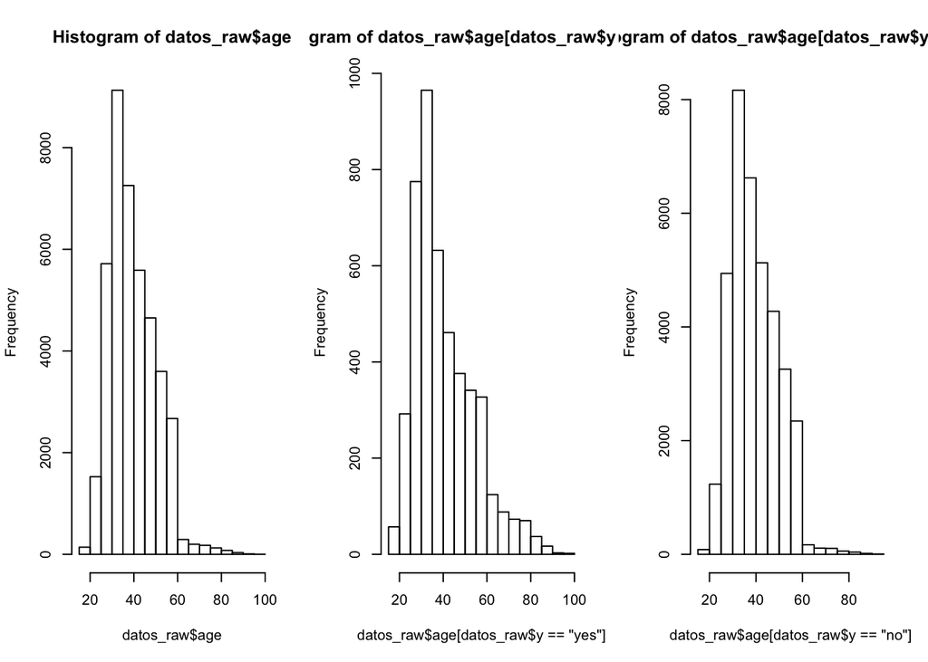

```r
par(mfrow=c(1,3))
hist(datos_raw$age)
hist(datos_raw$age[datos_raw$y == "yes"])
hist(datos_raw$age[datos_raw$y == "no"])
```

Las tres distribuciones se parecen bastante entre si. ¿Cómo difieren las edades entre los tres grupos?

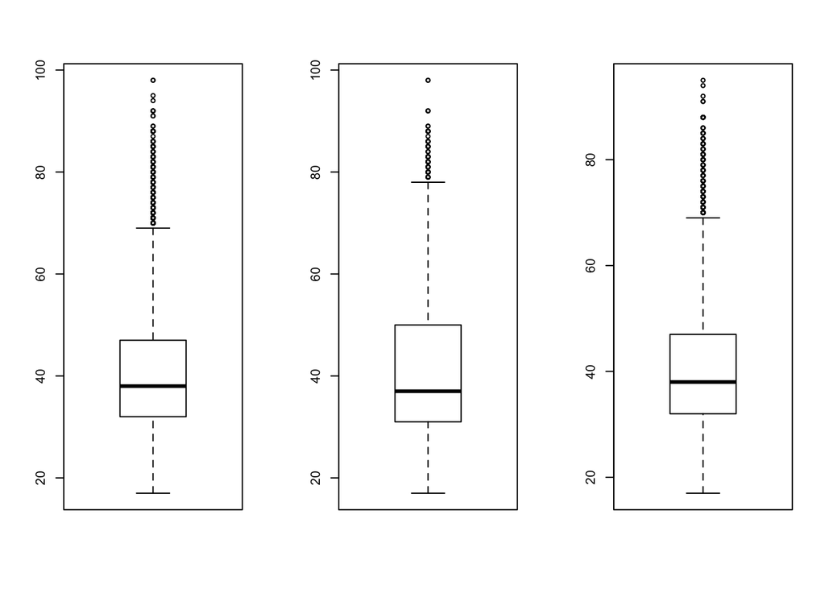

```r
par(mfrow=c(1,3))
boxplot(datos_raw$age)
boxplot(datos_raw$age[datos_raw$y == "yes"])
boxplot(datos_raw$age[datos_raw$y == "no"])
```

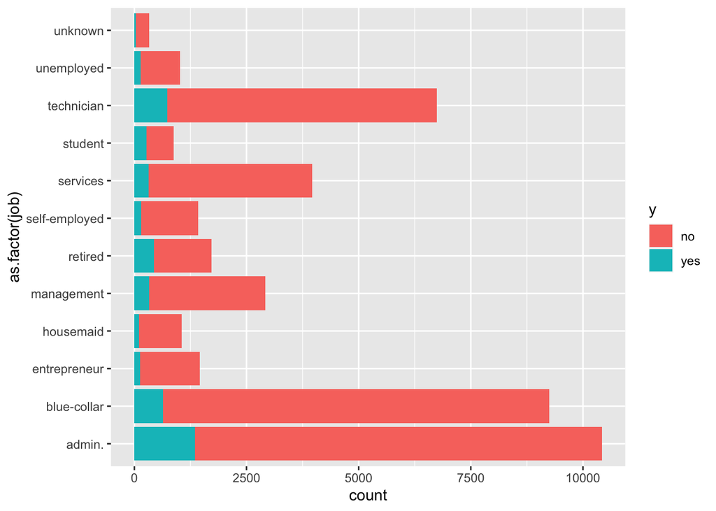

```r
# Learn about this chart at
# https://www.r-graph-gallery.com/218-basic-barplots-with-ggplot2.html
library(ggplot2)
ggplot(datos_raw, aes(x = as.factor(job), fill = y)) + geom_bar() + coord_flip()
```

Como vemos en la gráfica, en valores absolutos los administradores y técnicos compraron más servicios bancarios, pero eso no explica su valor relativo. Hagamos el análisis consecuente.

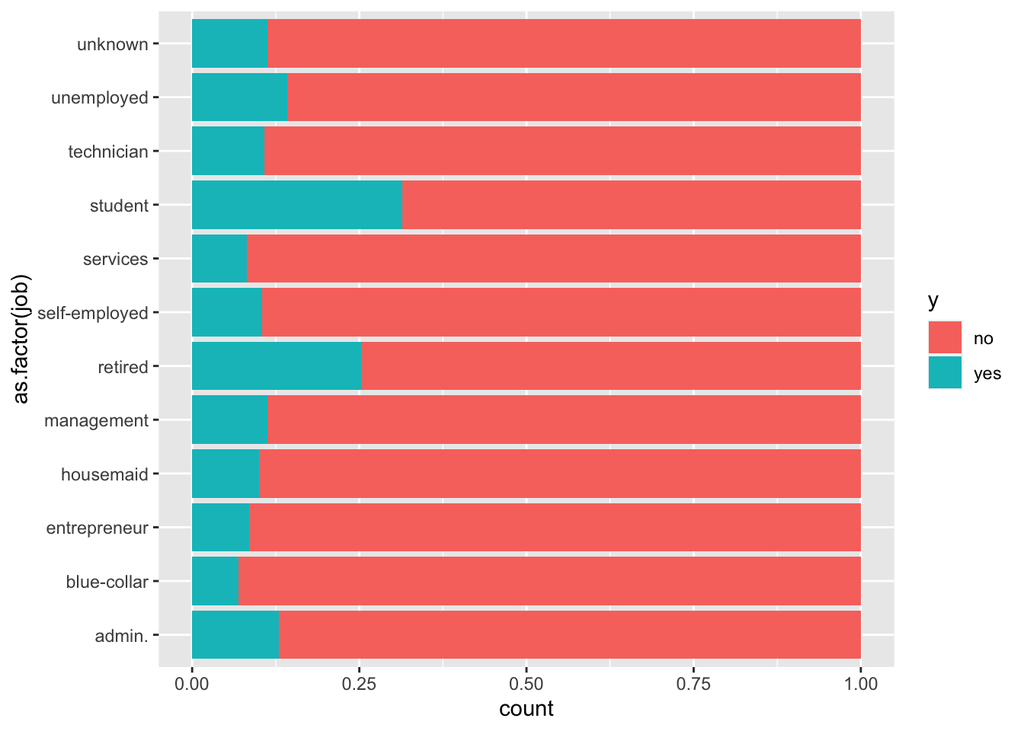

```r
# Learn about this chart at
# https://www.r-graph-gallery.com/218-basic-barplots-with-ggplot2.html
ggplot(datos_raw, aes(x = as.factor(job), fill = y)) + geom_bar(position = "fill") + coord_flip()
```

Desde el punto de vista relativo, los estudiantes y retirados contratan más servicios bancarios.

Este problema nos lleva a pensar en las distribuciones marginales.

```r
tabla <- table(datos_raw$y, datos_raw$job)
addmargins(tabla)
```

```
##
##       admin. blue-collar entrepreneur housemaid management retired
##   no    9070        8616         1332       954       2596    1286
##   yes   1352         638          124       106        328     434
##   Sum  10422        9254         1456      1060       2924    1720
##
##       self-employed services student technician unemployed unknown   Sum
##   no           1272     3646     600       6013        870     293 36548
##   yes           149      323     275        730        144      37  4640
##   Sum          1421     3969     875       6743       1014     330 41188
```

```r
tabla_prop <- prop.table(x = tabla)
addmargins(tabla_prop)
```

```
##
##             admin.  blue-collar entrepreneur    housemaid   management
##   no  0.2202097698 0.2091871419 0.0323395164 0.0231620860 0.0630280664
##   yes 0.0328250947 0.0154899485 0.0030105856 0.0025735651 0.0079634845
##   Sum 0.2530348645 0.2246770904 0.0353501020 0.0257356512 0.0709915509
##
##            retired self-employed     services      student   technician
##   no  0.0312226862  0.0308827814 0.0885209284 0.0145673497 0.1459891230
##   yes 0.0105370496  0.0036175585 0.0078420899 0.0066767020 0.0177236088
##   Sum 0.0417597358  0.0345003399 0.0963630184 0.0212440517 0.1637127319
##
##         unemployed      unknown          Sum
##   no  0.0211226571 0.0071137224 0.8873458289
##   yes 0.0034961639 0.0008983199 0.1126541711
##   Sum 0.0246188210 0.0080120423 1.0000000000
```

### La Educación y los Productos Bancarios

El pensamiento común dice que la gente con más educación debiera gravitar más al ahorro y los productos bancarios. ¿Pero es verdad? Veamos los resultados con una gráfica detallada.

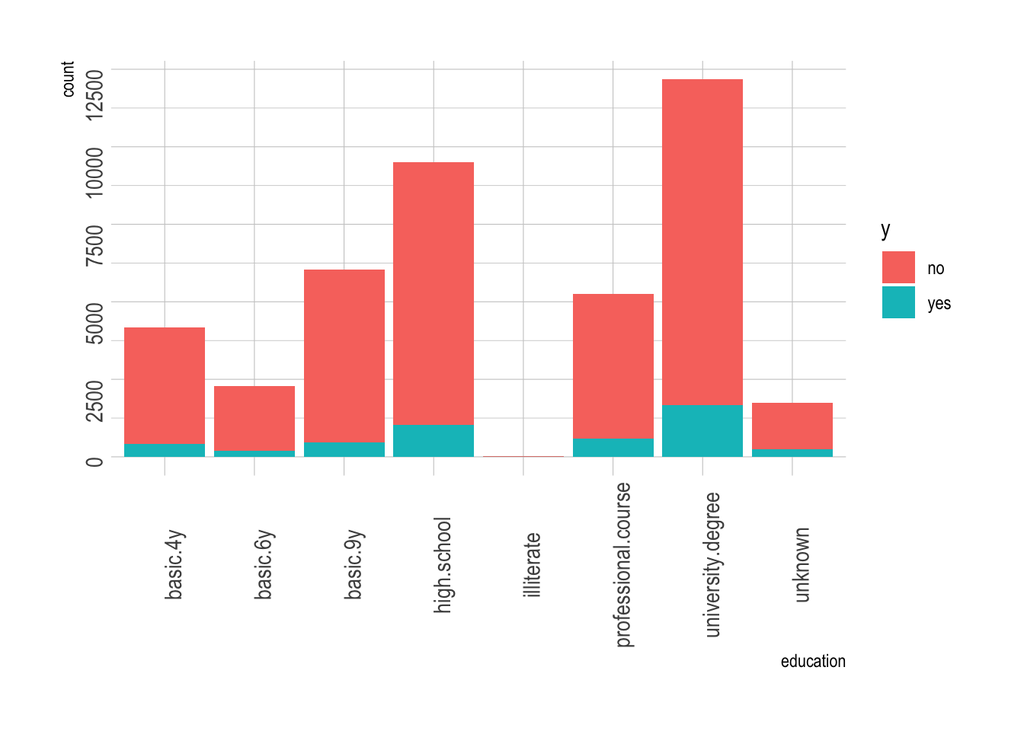

```r
library(ggplot2)
library(viridis)
library(hrbrthemes)

ggplot(datos_raw, aes(x = education, fill = y)) +
  geom_bar() +
  theme_ipsum() +
  theme(axis.text = element_text( angle = 90))
```